# CJDavis Midterm1-1

### 2301 Fall 2021

#### Midterm 1: sets, vectors and Booleans

#### Academic honesty policy [1 pts]

**You must complete this by signing your name**

You are expected to complete your midterm on your own. You are welcome to use any course materials to complete the exam. You are not permitted to copy code or answers from other students, or copy materials you find online. I will run plagiarism checking software to detect copied work. Any violations will be considered a breach of CU Boulder's [honor code](https://www.colorado.edu/sccr/honor-code), and I will take steps to ensure accountability.

It is very important to me that you complete the midterm honestly. Completing the exam honestly will help me understand what you know in order to guide the direction of the class. It will also help you gain experience with foundational concepts you will use throughout your entire career in information science. Please do not allow a short-term focus on grades to lead you to cheat, at the cost of your long-term learning.

Once you have read the above statement, please type [your name here] to indicate your comittement to completing the exam on your own.

$Christopher Davis$

#### Q1. Basics of sets [19 pts]

Let set $A =\{3,1,8\}$ and let $B=\{1,8,2\}$ and let $ U=\{1,2,3,4,5,6,7,8,9,10\} $ where $U$ is the set of all elements.

Part 1. [9 pts]

$A \cap B$ =

Answer by writing out the members of a set using the set notation we learned in class.

### $A \cap B = \{1,8\} $

Part 2. [10 pts]

Let set $C =\{1,4,9\}$ and let $D=\{1,6,9\}$

$\overline{C \cup D}$ = ?

Answer by writing out the members of a set using the set notation we learned in class.

### ${C \cup D} = \{1,4,6,9\}$ Therefore $\overline{C \cup D}$ (all elements in $U$, NOT in ${C \cup D}) = \{2,3,5,7,8,10\}$

#### Q2. Describing your intuitions about sets in words [10 pts]

The null set is an empty set, with no elements. The null set can be written $\emptyset$. Thus, $\emptyset = \{ \}$

Say that you have sets $A$ and $B$, where $A \subset B$ and where $ \vert A \vert > 0$. Is it the case that $ \vert B \vert > \vert \emptyset \vert $?

Answer yes or no. Explain why it is or is not the case that $\vert B \vert > \vert \emptyset \vert$ using a few short English sentences that clearly and convincingly explain your answer. Pretend like you are explaining to a fellow classmate who is confused about this.

You may want to use a picture or diagrams to support your argument. You can upload any diagrams that you draw to help with your explanation to Canvas. Just be clear to be clear about which diagram corresponds to Q2.

$A$ is a subset of $B$ and $A$ has 1 or more elements. If $A$ is a "proper subset," then $B$ must have at least one more element than $A$. Cardinality is similar to absolute value in that you must have a positive number, or zero. In this case, it is a positive number of elements, or zero. What is the cardinality of a null or empty set? The number of elements in the set is zero, so the cardinality has to be zero. Therfore the cardinality of $\vert B\vert$ must be greater than $\vert\emptyset\vert$. It is also informative to consider that $\vert B\vert$ has to be greater than $\vert A\vert$ which is itself $\vert A\vert>0$. The only odd case that is possible (but not in this example), is $A\subseteq B$ where $\vert B\vert$ *might* = $\vert A\vert$.

### Q3. Vectors and vector operations [10 pts]

Imagine we have three documents represented as 2-D vectors.

- $\boldsymbol{x}$ = $<9, 2>$
- $\boldsymbol{y}$ = $<-1, 4>$
- $\boldsymbol{z}$ = $<-2, 6>$

Part 1. [5 pts]

Normalize each vector and report your answer below. You must show your work to receive full credit. You can upload a file to show your work, or write it out in the notebook. Just make sure your work is clear. Note that the small "hat" symbol (i.e. pointed triangle) over each vector below indicates it is a normalized vector. For instance, $\hat{x}$ is the normalized vector $\boldsymbol{x}$.

- $\hat{{x}} = < ... > $
- $\hat{{y}} = < ... >$
- $\hat{{z}} = < ... >$

$x =<9,2>$ then the (Euclidean) norm is:

$\|x\|_2=\sqrt{9^2 + 2^2} = \sqrt{81+4} = \sqrt{85} = 9.2195 $

The unit vector of $x$ is $ \hat{\boldsymbol{x}} $ = $<\frac{9}{\sqrt{85}},\frac{2}{\sqrt{85}}>$ = $<.976,.217>$

Check: $\sqrt{\left(\frac{9}{\sqrt{85}}\right)^{2}+\left(\frac{2}{\sqrt{85}}\right)^{2}}=\sqrt{\frac{81}{85}+\frac{4}{85}}=1$

$y =<−1,4>$ then the (Euclidean) norm is:

$\|y\|_2=\sqrt{-1^2 + 4^2} = \sqrt{1+16} = \sqrt{17}= 4.1231 $

The unit vector of $y$ is $ \hat{\boldsymbol{y}} $ = $<\frac{-1}{\sqrt{17}},\frac{4}{\sqrt{17}}>$ = $<-.243,.970>$

Check: $\sqrt{\left(\frac{-1}{\sqrt{17}}\right)^{2}+\left(\frac{4}{\sqrt{17}}\right)^{2}}=\sqrt{\frac{1}{17}+\frac{16}{17}}=1$

$z =<−2,6>$ then the (Euclidean) norm is:

$\|z\|_2=\sqrt{-2^2 + 6^2} = \sqrt{4+36} = \sqrt{40} = 6.325$

The unit vector of $z$ is $ \hat{\boldsymbol{z}} $ = $<\frac{-2}{\sqrt{40}},\frac{6}{\sqrt{40}}>$ = $<-.316,.949>$

Check: $\sqrt{\left(\frac{-2}{\sqrt{40}}\right)^{2}+\left(\frac{6}{\sqrt{36}}\right)^{2}}=\sqrt{\frac{4}{40}+\frac{36}{40}}=1$

Part 2. [5 pts]

Is $\hat{{x}}$ or $\hat{{y}}$ closer to $\hat{{z}}$ in 2-dimensional space? Explain your answer in words and symbols using the geometric definition of the dot product described in the outline and in lecture. Your answer should be a few short sentences. As part of your answer, plot each vector in 2D. You can upload an image or hand-drawn diagram, just make sure it is clear how you are answering Q3. Hint: you might want to start by writing out the geometric definition of the dot product.

Plotting the unit vectors clearly shows the radial distance of $ \hat{\boldsymbol{y}} $ close to $ \hat{\boldsymbol{z}} $ while $ \hat{\boldsymbol{x}} $ is far away.

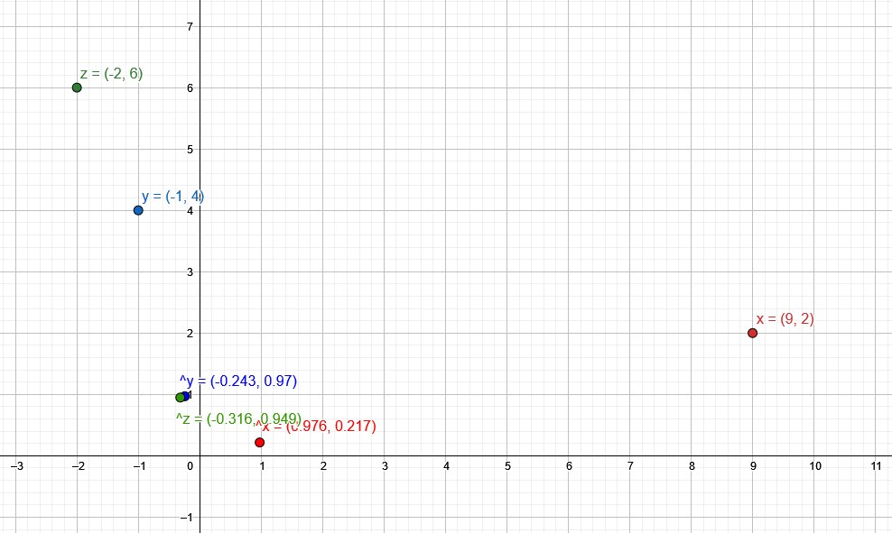

According to dot product:

given

- $\boldsymbol{x}$ = $<9, 2>$
- $\boldsymbol{z}$ = $<-2, 6>$

$\boldsymbol{x} \cdot \boldsymbol{z}=\sum_{i} \boldsymbol{x}_{i} \boldsymbol{z}_{i}$

$= 9 ∗ −2 + 2 ∗ 6 $

$= -18 + 12 = -6$

and given

- $\boldsymbol{y}$ = $<-1, 4>$
- $\boldsymbol{z}$ = $<-2, 6>$

$\boldsymbol{y} \cdot \boldsymbol{z}=\sum_{i} \boldsymbol{y}_{i} \boldsymbol{z}_{i}$

$= -1 ∗ −2 + 4 ∗ 6 $

$= 2 + 24 = 26$

So $\boldsymbol{x} \cdot \boldsymbol{z}= -6$ and $\boldsymbol{y} \cdot \boldsymbol{z}= 26$ ... clearly larger.

According to the outline we can compare the projections as if the sun cast a shadow and see if the angle $θ$ is *negative, 0, or positive.* Below I rotate the same graph as above to place the **z** vector horizontal, as a base leg, and illustrate **x** casts a "negative" shadow, while **y** casts a "positive" shadow.

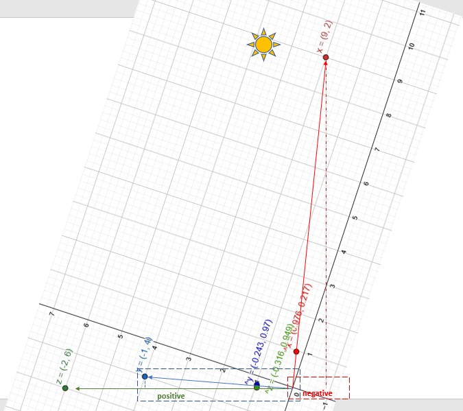

### Q4. Max norm [10 pts]

The max norm of a vector $\boldsymbol{x}$ is defined as the largest element in $\boldsymbol{x}$, by absolute value.

For instance, the max norm of $\boldsymbol{x}=<4,-7>$ is 7 because $\vert \boldsymbol{x}_2 \vert =7$ and $\boldsymbol{x}_2$ has the highest absolute value from among components of $\boldsymbol{x}$.

The max norm of $\boldsymbol{x}=<12,-2,44>$ is 44.

More formally, we can define

maxnorm($\boldsymbol{x}$) = max$(\vert \boldsymbol{x}_1 \vert, \vert \boldsymbol{x}_2 \vert ... \vert \boldsymbol{x}_N \vert)$ where max returns the highest input and $\vert \boldsymbol{x}_i \vert$ is the absolute value of component $i$ of $\boldsymbol{x}$.

Implement the maxnorm function in midterm_1_part2.py and turn in this file along with your midterm.

```python
## from midterm_1_part2.py

def max_norm(x):
    iMax = 0
    for i in x:
        if iMax < abs(i):  # we know we have a higher absolute value
            iMax = abs(i)  # set the iMax value to it
    return iMax            # we are done with the loop.  return what we have.

A = [1, -20, 3]
max_norm(A)
```

```
20
```